# Titanic_missing

```python
import pandas as pd
import numpy as np
import seaborn as sns
import matplotlib.pyplot as plt
import matplotlib.mlab as mlab
```

```python
titanic = pd.read_csv("data/titanic.csv")
```

```python
titanic.head()
```

|  | PassengerId | Survived | Pclass | Name | Sex | Age | SibSp | Parch | Ticket | Fare | Cabin | Embarked |
| --- | --- | --- | --- | --- | --- | --- | --- | --- | --- | --- | --- | --- |
| 0 | 1 | 0 | 3 | Braund, Mr. Owen Harris | male | 22.0 | 1 | 0 | A/5 21171 | 7.2500 | NaN | S |
| 1 | 2 | 1 | 1 | Cumings, Mrs. John Bradley (Florence Briggs Th... | female | 38.0 | 1 | 0 | PC 17599 | 71.2833 | C85 | C |
| 2 | 3 | 1 | 3 | Heikkinen, Miss. Laina | female | 26.0 | 0 | 0 | STON/O2. 3101282 | 7.9250 | NaN | S |
| 3 | 4 | 1 | 1 | Futrelle, Mrs. Jacques Heath (Lily May Peel) | female | 35.0 | 1 | 0 | 113803 | 53.1000 | C123 | S |
| 4 | 5 | 0 | 3 | Allen, Mr. William Henry | male | 35.0 | 0 | 0 | 373450 | 8.0500 | NaN | S |

## Обнаружение пропусков

### Рассмотрим несколько способов

### 1. Визуализация пропущеных данных с помощью тепловой карты

Когда признаков в наборе не очень много, пропущенные значения можно визуализировать с помощью **тепловой карты**.

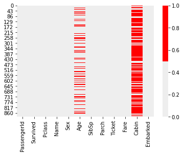

```python
cols = titanic.columns[:]
# определяем цвета
# красный - пропущенные данные
colours = ['#eeeeee', '#ff0000']
sns.heatmap(titanic[cols].isnull(), cmap=sns.color_palette(colours))
```

Заметно, например, что признак Cabin имеет довольно много пустых строк, а признак Age – поменьше, но тоже достаточно много

### 2. Проверяем на наличие нулевых значений

```python
# проверка на наличие нулевых значений по столбцам
titanic.isnull().any()
```

```
PassengerId    False
Survived       False
Pclass         False
Name           False
Sex            False
Age             True
SibSp          False
Parch          False
Ticket         False
Fare           False
Cabin           True
Embarked        True
dtype: bool
```

### 3. Подсчитаем количество нулевых значений по столбцам

```python
for col in titanic.columns:
    pct_missing = titanic[col].isnull().sum()
    print('{} - {}'.format(col, round(pct_missing)))
```

```
PassengerId - 0
Survived - 0
Pclass - 0
Name - 0
Sex - 0
Age - 177
SibSp - 0
Parch - 0
Ticket - 0
Fare - 0
Cabin - 687
Embarked - 2
```

### 4. Подсчитаем процент нулевых значений по столбцам

Если в наборе много признаков и визуализация занимает много времени, можно рассчитать процент отсутствующих записей для каждого признака.

```python
for col in titanic.columns:
    pct_missing = np.mean(titanic[col].isnull())
    print('{} - {}%'.format(col, round(pct_missing*100)))
```

```
PassengerId - 0%
Survived - 0%
Pclass - 0%
Name - 0%
Sex - 0%
Age - 20%
SibSp - 0%
Parch - 0%
Ticket - 0%
Fare - 0%
Cabin - 77%
Embarked - 0%
```

Видно, что в поле Age отсуствует 20% записей, а в Cabin - целых 77%

### Что делать с пропущенными значениями?

Не существует общих решений для проблемы отсутствующих данных. Для каждого конкретного набора приходится искать наиболее подходящие методы или их комбинации.

Можно удалить все записи и столбцы с пропущенными значениями, НО в таком случае мы потеряем данные (см.рис)

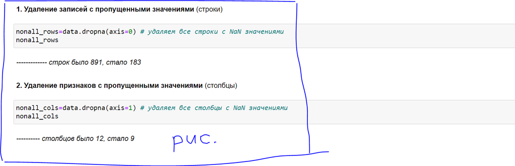

### Что бы не удалять все подряд будем делать это с умом, рассуждаем:

**Столбцы Age, Cabin и Embarked содержат NaN, которые нужно исключить или заменить.**  
Наша задача по входным параметрам предсказать выживет пассажир или нет (задача классификации).  
Для этого будем рассуждать:  
Возраст важен? - Да, значит оставляем и заменяем пропуски по смыслу  
Номер кабины важен? - вероятно нет и можно удалить этот столбик  
Порт посадки важен? - вероятно нет (а может и ДА), но здесь только 2 пропуска, можно заменить на моду

**Удалим столбец Cabin, так как в нем наибольшее количество пропусков, к тому же номер кабины не важен для нашей задачи**

```python
#titanic=titanic.drop(["Cabin","Embarked"],axis=1)
titanic=titanic.drop(["Cabin"],axis=1)
titanic.head()
```

|  | PassengerId | Survived | Pclass | Name | Sex | Age | SibSp | Parch | Ticket | Fare | Embarked |
| --- | --- | --- | --- | --- | --- | --- | --- | --- | --- | --- | --- |
| 0 | 1 | 0 | 3 | Braund, Mr. Owen Harris | male | 22.0 | 1 | 0 | A/5 21171 | 7.2500 | S |
| 1 | 2 | 1 | 1 | Cumings, Mrs. John Bradley (Florence Briggs Th... | female | 38.0 | 1 | 0 | PC 17599 | 71.2833 | C |
| 2 | 3 | 1 | 3 | Heikkinen, Miss. Laina | female | 26.0 | 0 | 0 | STON/O2. 3101282 | 7.9250 | S |
| 3 | 4 | 1 | 1 | Futrelle, Mrs. Jacques Heath (Lily May Peel) | female | 35.0 | 1 | 0 | 113803 | 53.1000 | S |
| 4 | 5 | 0 | 3 | Allen, Mr. William Henry | male | 35.0 | 0 | 0 | 373450 | 8.0500 | S |

**Пустые значения в поле Age логично заменить на среднее**

```python
titanic["Age"]=titanic["Age"].fillna(titanic["Age"].mean())
titanic["Age"]
```

```
0      22.000000
1      38.000000
2      26.000000
3      35.000000
4      35.000000
         ...
886    27.000000
887    19.000000
888    29.699118
889    26.000000
890    32.000000
Name: Age, Length: 891, dtype: float64
```

```python
# Заменим пропуски в Embarked на моду
# titanic["Embarked"]=titanic["Embarked"].fillna(titanic["Embarked"].modе())
# ---- почему-то не получилось ??
# ---- значит найдем моду отдельно и подставим значение моды в функцию fillna
```

```python
titanic["Embarked"].mode()
```

```
0    S
dtype: object
```

```python
titanic["Embarked"]=titanic["Embarked"].fillna('S')
```

### Для применения методов машинного обучения выборка должна содержать только числовые параметры

### 1 Проверим тип данных нашего датасета

```python
titanic.dtypes
```

```
PassengerId      int64
Survived         int64
Pclass           int64
Name            object
Sex             object
Age            float64
SibSp            int64
Parch            int64
Ticket          object
Fare           float64
Embarked        object
dtype: object
```

### 2 Заменим текст числами

```python
# функция map() используется для применения функции к каждому элементу итерируемого объекта
titanic["Sex"]=titanic["Sex"].map({"male": 1, "female": 0})
titanic.head()
```

|  | PassengerId | Survived | Pclass | Name | Sex | Age | SibSp | Parch | Ticket | Fare | Embarked |
| --- | --- | --- | --- | --- | --- | --- | --- | --- | --- | --- | --- |
| 0 | 1 | 0 | 3 | Braund, Mr. Owen Harris | 1 | 22.0 | 1 | 0 | A/5 21171 | 7.2500 | S |
| 1 | 2 | 1 | 1 | Cumings, Mrs. John Bradley (Florence Briggs Th... | 0 | 38.0 | 1 | 0 | PC 17599 | 71.2833 | C |
| 2 | 3 | 1 | 3 | Heikkinen, Miss. Laina | 0 | 26.0 | 0 | 0 | STON/O2. 3101282 | 7.9250 | S |
| 3 | 4 | 1 | 1 | Futrelle, Mrs. Jacques Heath (Lily May Peel) | 0 | 35.0 | 1 | 0 | 113803 | 53.1000 | S |
| 4 | 5 | 0 | 3 | Allen, Mr. William Henry | 1 | 35.0 | 0 | 0 | 373450 | 8.0500 | S |

Таким же образом нужно изменить текст в столбце Embarked на числа. Для этого узнаем какие значения есть в этом столбце.

```python
titanic['Embarked'].value_counts()
```

```
S    646
C    168
Q     77
Name: Embarked, dtype: int64
```

```python
# функция map() используется для применения функции к каждому элементу итерируемого объекта
titanic["Embarked"]=titanic["Embarked"].map({"S": 1, "C": 2, "Q":3})
titanic.head()
```

|  | PassengerId | Survived | Pclass | Name | Sex | Age | SibSp | Parch | Ticket | Fare | Embarked |
| --- | --- | --- | --- | --- | --- | --- | --- | --- | --- | --- | --- |
| 0 | 1 | 0 | 3 | Braund, Mr. Owen Harris | 1 | 22.0 | 1 | 0 | A/5 21171 | 7.2500 | 1 |
| 1 | 2 | 1 | 1 | Cumings, Mrs. John Bradley (Florence Briggs Th... | 0 | 38.0 | 1 | 0 | PC 17599 | 71.2833 | 2 |
| 2 | 3 | 1 | 3 | Heikkinen, Miss. Laina | 0 | 26.0 | 0 | 0 | STON/O2. 3101282 | 7.9250 | 1 |
| 3 | 4 | 1 | 1 | Futrelle, Mrs. Jacques Heath (Lily May Peel) | 0 | 35.0 | 1 | 0 | 113803 | 53.1000 | 1 |
| 4 | 5 | 0 | 3 | Allen, Mr. William Henry | 1 | 35.0 | 0 | 0 | 373450 | 8.0500 | 1 |

### 3. Колонки Name и Ticket тоже не содержат важной для спасения человека информации, удаляем эти столбцы

```python
titanic=titanic.drop(["Name","Ticket"],axis=1)
titanic.head()
```

|  | PassengerId | Survived | Pclass | Sex | Age | SibSp | Parch | Fare | Embarked |
| --- | --- | --- | --- | --- | --- | --- | --- | --- | --- |
| 0 | 1 | 0 | 3 | 1 | 22.0 | 1 | 0 | 7.2500 | 1 |
| 1 | 2 | 1 | 1 | 0 | 38.0 | 1 | 0 | 71.2833 | 2 |
| 2 | 3 | 1 | 3 | 0 | 26.0 | 0 | 0 | 7.9250 | 1 |
| 3 | 4 | 1 | 1 | 0 | 35.0 | 1 | 0 | 53.1000 | 1 |
| 4 | 5 | 0 | 3 | 1 | 35.0 | 0 | 0 | 8.0500 | 1 |

```python
titanic.dtypes # Проверим на наличие нечисловых значений
```

```
PassengerId      int64
Survived         int64
Pclass           int64
Sex              int64
Age            float64
SibSp            int64
Parch            int64
Fare           float64
Embarked         int64
dtype: object
```

**Кроме того преобразования позволили сократить память (см.рис)**

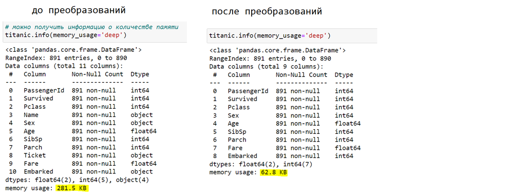

### Баллансировка данных

**Рекомендуется, чтобы распределение объектов по разным классам было более менее равномерным, иначе модель, обученная на данных с преобладающим большинством объектов одного класса, будет классифицировать все объекты как объекты преобладающего класса.** Например, если объектов класса А 95%, то почти все новые объекты будут классифицированы как класс А, независимо от их принадлежности классу В

```python
titanic["Survived"].value_counts() # Количество выживших и утонувших
```

```
0    549
1    342
Name: Survived, dtype: int64
```

В нашем случае хоть и преобладает класс 0, но такое отклонение допустимо, хотя, не исключено, что при равном распределении по классам, модель покажет лучшие результаты Подробнее о баллансировке данных https://loginom.ru/blog/imbalance-class

**Сохраним подготовленный датасет в csv-файл для дальнейшей работы**

```python
titanic.to_csv("data/titanic_clear.csv")
```

**Теперь можно приступить к обучению модели**

## !!!Задание на самостоятельную работу

**1. Загрузить датасет с пропученными значениями diabetes.csv**  
**2. Проделать работу по очистке данных по примеру данного файла (или по своему примеру)**